# Multivariate Disease Mapping

Leiwen Gao, Sudipto Banerjee

6/23/2021

### 1. Load California map and packages

```r
##### Libraries for sptial information in map, map projection and map ploting
library(maps)
#Import California map with counties
ca.county = map("county","california", fill=TRUE, plot=FALSE)
library(mapproj)
library(spdep)
library(maptools)
library(classInt)
library(RColorBrewer)

##### Libraries for matrix, distribution and math computation
library(mvtnorm)
library(matrixStats)
library(blockmatrix)
library(Matrix)
library(invgamma)
library(mnormt)
library(MASS)
library(Hmisc) #rcorr
library(gtools) #permutation
#library(fields)
#library(msos)
#library(boot)
#library(ggmcmc)

#library(mcmc)
#library(magic)

#library(AICcmodavg)
#library(coda)

##### Libraries for JAGS
library(rjags)
library(R2jags)

##### Draw plots
library(ggplot2)

##### Data management
library(tidyr)

##### Import and export documents
library(knitr)
library(readr)

##### Bayesian inference
library(LaplacesDemon)

##### Model selection
library(bridgesampling)
```

### 2. Dataset exploration and visualization

#### 2.1 Import dataset (county-level) extracted from SEER

Cancers: lung, esophageal, larynx and colorectal

Outcome: 5-year average age-adjusted incidence rates (age-adjusted to the 2000 U.S. Standard Population) per 100,000 population in the years from 2012 to 2016

Covariates (percentage): adult cigarette smoking rates, percentages of residents younger than 18 years old, older than 65 years old, with education level below high school, percentages of unemployed residents, black residents, male residents, uninsured residents, and percentages of families below the poverty threshold

```r
#Import covariates
covariates <- read.csv("data/covariates.csv")
race <- read.csv("data/race.csv")
sex <- read.csv("data/sex.csv")
insurance <- read.csv("data/insurance.csv")
smoking <- read.csv("data/smoking.csv")
smoking$smoking <- as.numeric(substr(smoking$Cigarette.Smoking.Rate., 1,4))

#Import age-adjusted incidence rates for 4 cancers in California
rate_5y <- read.csv("data/age_adjusted.csv")
rate_CA = rate_5y[substr(rate_5y$State_county,1,2) == "CA",]

rate_lung = rate_CA[rate_CA$Site_recode_ICD_O_3_WHO_2008=="Lung and Bronchus",]
rate_lung = rate_lung[order(extract_numeric(rate_lung$State_county)),]

rate_esophagus = rate_CA[rate_CA$Site_recode_ICD_O_3_WHO_2008=="Esophagus",]
rate_esophagus = rate_esophagus[order(extract_numeric(rate_esophagus$State_county)),]

rate_larynx = rate_CA[rate_CA$Site_recode_ICD_O_3_WHO_2008=="Larynx",]
rate_larynx = rate_larynx[order(extract_numeric(rate_larynx$State_county)),]

rate_colrect = rate_CA[rate_CA$Site_recode_ICD_O_3_WHO_2008=="Colon and Rectum",]
rate_colrect = rate_colrect[order(extract_numeric(rate_colrect$State_county)),]

################## Data construction and adjacency matrix ###########

## Data

# Covariates in percentage
county_attribute = covariates[substr(covariates$State_county,1,2) == "CA",]
county_attribute$state = extract_numeric(county_attribute$State_county)
county_attribute1 = data.frame(county_attribute[order(county_attribute$state),])
county_attribute1$V_Persons_age_18_ACS_2012_2016 = as.numeric(county_attribute1$V_Persons_age_18_ACS_2012_2016)/100
county_attribute1$V_Persons_age_65_ACS_2012_2016 = as.numeric(county_attribute1$V_Persons_age_65_ACS_2012_2016)/100
county_attribute1$VHighschooleducationACS2012201 = as.numeric(county_attribute1$VHighschooleducationACS2012201)/100
county_attribute1$VFamiliesbelowpovertyACS201220 = as.numeric(county_attribute1$VFamiliesbelowpovertyACS201220)/100
county_attribute1$V_Unemployed_ACS_2012_2016 = as.numeric(county_attribute1$V_Unemployed_ACS_2012_2016)/100

race1 = race[substr(race$State_county,1,2) == "CA"&race$Race_recode_White_Black_Other=="Black",]
sex1 = sex[substr(sex$State_county,1,2) == "CA"&sex$Sex=="Male",]
insurance1 = insurance[substr(insurance$State_county,1,2) == "CA"&insurance$Insurance_Recode_2007=="Uninsured",]

# Create covariates matrix for each cancer
# For Case 1, all covariates are included; But smoking is excluded in covariates for Case 2.
rate_lung1 = cbind(rate_lung, smoking$smoking, county_attribute1[,2:6], race1$Row_Percent, sex1$Row_Percent,insurance1$Row_Percent)
colnames(rate_lung1) = c("county", "site", "rate", "count", "population", "smoking", "young","old", "highschool", "poverty", "unemployed", "black", "male", "uninsured")
rate_esophagus1 = cbind(rate_esophagus, smoking$smoking, county_attribute1[,2:6], race1$Row_Percent, sex1$Row_Percent,insurance1$Row_Percent)
colnames(rate_esophagus1) = c("county", "site", "rate", "count", "population", "smoking", "young","old", "highschool", "poverty", "unemployed", "black", "male", "uninsured")
rate_larynx1 = cbind(rate_larynx, smoking$smoking, county_attribute1[,2:6], race1$Row_Percent, sex1$Row_Percent,insurance1$Row_Percent)
colnames(rate_larynx1) = c("county", "site", "rate", "count", "population", "smoking", "young","old", "highschool", "poverty", "unemployed", "black", "male", "uninsured")
rate_colrect1 = cbind(rate_colrect, smoking$smoking, county_attribute1[,2:6], race1$Row_Percent, sex1$Row_Percent,insurance1$Row_Percent)
colnames(rate_colrect1) = c("county", "site", "rate", "count", "population", "smoking", "young","old", "highschool", "poverty", "unemployed", "black", "male", "uninsured")
```

#### 2.2 Combine cancer data with the California map for each county

To plot the cancer data, we need to combine the data with the map polygon

```r
#County information
county.ID <- sapply(strsplit(ca.county$names, ","), function(x) x[2])
ca.poly = map2SpatialPolygons(ca.county, IDs=county.ID)
ca.poly$rate_lung = rate_lung$Age_Adjusted_Rate
ca.poly$rate_esophagus = rate_esophagus$Age_Adjusted_Rate
ca.poly$rate_larynx = rate_larynx$Age_Adjusted_Rate
ca.poly$rate_colrect = rate_colrect$Age_Adjusted_Rate
ca.poly$smoking = smoking$smoking

ca.coords = coordinates(ca.poly)
```

#### 2.3 Plots for raw incidence data and important covariates

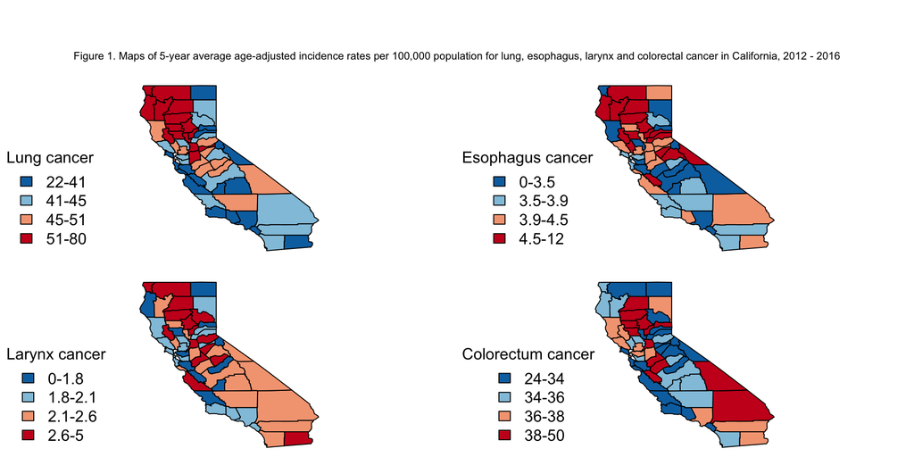

```r
##################### Plot age-adjusted incidence rates in areal map ##################

brks_fit_lung = c(22, 41, 45, 51, 80)
brks_fit_esophagus = c(0, 3.5, 3.9, 4.5, 12)
brks_fit_larynx = c(0, 1.8, 2.1, 2.6, 5)
brks_fit_colrect = c(24, 34, 36, 38, 50)

color.pallete = rev(brewer.pal(4,"RdBu"))
class.rate_lung = classIntervals(var=ca.poly$rate_lung, n=4, style="fixed",
                                 fixedBreaks=brks_fit_lung, dataPrecision=4)
class.rate_esophagus = classIntervals(var=ca.poly$rate_esophagus, n=4, style="fixed",
                                      fixedBreaks=brks_fit_esophagus, dataPrecision=4)
class.rate_larynx = classIntervals(var=ca.poly$rate_larynx, n=4, style="fixed",
                                   fixedBreaks=brks_fit_larynx, dataPrecision=4)
class.rate_colrect = classIntervals(var=ca.poly$rate_colrect, n=4, style="fixed",
                                    fixedBreaks=brks_fit_colrect, dataPrecision=4)
color.code.rate_lung = findColours(class.rate_lung, color.pallete)
color.code.rate_esophagus = findColours(class.rate_esophagus, color.pallete)
color.code.rate_larynx = findColours(class.rate_larynx, color.pallete)
color.code.rate_colrect = findColours(class.rate_colrect, color.pallete)

par(mfrow=c(2,2), oma = c(0,0,4,0) + 0.1, mar = c(0,0,1,0) + 0.1)

plot(ca.poly, col = color.code.rate_lung)
leg.txt1 = c("22-41", "41-45", "45-51","51-80")
legend("bottomleft", title="Lung cancer", legend=leg.txt1, cex=1.25, bty="n", horiz = FALSE,
       fill = color.pallete)

plot(ca.poly, col = color.code.rate_esophagus)
leg.txt2 = c("0-3.5", "3.5-3.9", "3.9-4.5", "4.5-12")
legend("bottomleft", title="Esophagus cancer",legend=leg.txt2, cex=1.25, bty="n", horiz = FALSE,
       fill = color.pallete)

plot(ca.poly, col = color.code.rate_larynx)
leg.txt3 = c("0-1.8", "1.8-2.1", "2.1-2.6", "2.6-5")
legend("bottomleft", title="Larynx cancer",legend=leg.txt3, cex=1.25, bty="n", horiz = FALSE,
       fill = color.pallete)


plot(ca.poly, col = color.code.rate_colrect)
leg.txt4 = c("24-34", "34-36", "36-38", "38-50")
legend("bottomleft",title="Colorectum cancer", legend=leg.txt4, cex=1.25, bty="n", horiz = FALSE,
       fill = color.pallete)

mtext("Figure 1. Maps of 5-year average age-adjusted incidence rates per 100,000 population for lung, esophagus, larynx and colorectal cancer in California, 2012 - 2016", outer = TRUE, cex = 0.7)
```

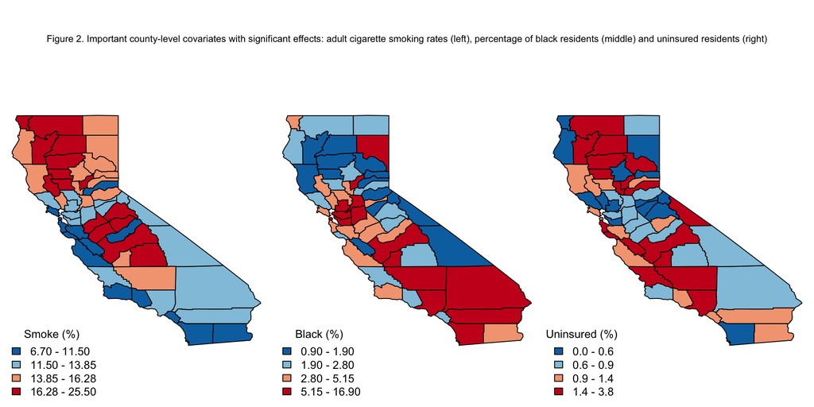

```r
###### Areal map for three important covariates: smoking, black and uninsure ############

ca.poly$black = race1$Row_Percent
ca.poly$smoke = smoking$smoking
ca.poly$uninsure = insurance1$Row_Percent

brks_fit_black = quantile(ca.poly$black)
class.black = classIntervals(var=ca.poly$black, n=4, style="fixed",
                             fixedBreaks=brks_fit_black, dataPrecision=4)
color.code.black = findColours(class.black, color.pallete)
brks_fit_smoke = quantile(ca.poly$smoke)
class.smoke = classIntervals(var=ca.poly$smoke, n=4, style="fixed",
                             fixedBreaks=brks_fit_smoke, dataPrecision=4)
color.code.smoke = findColours(class.smoke, color.pallete)
brks_fit_uninsure = quantile(ca.poly$uninsure)
class.uninsure = classIntervals(var=ca.poly$uninsure, n=4, style="fixed",
                             fixedBreaks=brks_fit_uninsure, dataPrecision=4)
color.code.uninsure = findColours(class.uninsure, color.pallete)

par(mfrow=c(1,3), oma = c(0,0,4,0) + 0.1, mar = c(0,0,1,0) + 0.1)

plot(ca.poly, col = color.code.smoke)
leg.txt = c("6.70 - 11.50", "11.50 - 13.85", "13.85 - 16.28", "16.28 - 25.50")
legend("bottomleft", title="Smoke (%)", legend=leg.txt, xpd = TRUE, cex=1.25, bty="n", horiz = FALSE,
       fill = color.pallete)

plot(ca.poly, col = color.code.black)
leg.txt = c("0.90 - 1.90", "1.90 - 2.80", "2.80 - 5.15", "5.15 - 16.90")
legend("bottomleft", title="Black (%)", legend=leg.txt, xpd = TRUE, cex=1.25, bty="n", horiz = FALSE,
       fill = color.pallete)

plot(ca.poly, col = color.code.uninsure)
leg.txt = c("0.0 - 0.6", "0.6 - 0.9", "0.9 - 1.4", "1.4 - 3.8")
legend("bottomleft", title="Uninsured (%)", legend=leg.txt, xpd = TRUE, cex=1.25, bty="n", horiz = FALSE,
       fill = color.pallete)

mtext("Figure 2. Important county-level covariates with significant effects: adult cigarette smoking rates (left), percentage of black residents (middle) and uninsured residents (right)", outer = TRUE, cex = 0.7)
```

#### 2.4 Create adjacency matrix for spatial information in directed graph (ordered regions)

The matrix ``Adj’’ is the adjacency matrix for counties in California. We reorder the counties starting from northwest to southeast for directed graph. Then we put all the islands (counties with no parent neighbors) at the beginning.

```r
ca.neighbors = poly2nb(ca.poly)
n=length(ca.neighbors)

# original adjacency matrix
Adj=sapply(ca.neighbors,function(x,n) {v=rep(0,n);v[x]=1;v},n)
colnames(Adj)=county.ID
ca.coord = coordinates(ca.poly)
ca.latrange=round(quantile(ca.coord[,2],c(0.25,0.75)))
ca.albersproj=mapproject(ca.coord[,1],ca.coord[,2],projection = "albers",param=ca.latrange)

# reorder counties from northwest to southeast
perm=order(ca.albersproj$x-ca.albersproj$y)
Adj_new=Adj[perm,perm]

n=nrow(Adj_new)
ni=rowSums(Adj_new)
maxn=max(ni)
neimat=matrix(0,n,maxn)
neighbors=lapply(1:n,function(x) which(Adj_new[x,]==1))
dneighbors=sapply(2:n,function(i) intersect(neighbors[[i]],1:(i-1)))
dni=sapply(dneighbors,length)
original_perm = 1:58
index2=c(1,which(dni==0)+1)

# final permutation for counties: put all the islands (counties with no parent neighbors) at the beginning
final_perm=c(original_perm[perm][index2],
             original_perm[perm][-index2])
colnames(Adj)[final_perm]
```

```
##  [1] "del norte"       "san francisco"   "humboldt"        "siskiyou"
##  [5] "trinity"         "shasta"          "modoc"           "mendocino"
##  [9] "tehama"          "glenn"           "lake"            "lassen"
## [13] "colusa"          "butte"           "sonoma"          "plumas"
## [17] "napa"            "sutter"          "yuba"            "marin"
## [21] "yolo"            "sierra"          "nevada"          "solano"
## [25] "placer"          "sacramento"      "contra costa"    "san mateo"
## [29] "el dorado"       "alameda"         "amador"          "san joaquin"
## [33] "santa cruz"      "calaveras"       "santa clara"     "alpine"
## [37] "stanislaus"      "tuolumne"        "merced"          "mariposa"
## [41] "san benito"      "monterey"        "mono"            "madera"
## [45] "fresno"          "kings"           "san luis obispo" "tulare"
## [49] "santa barbara"   "inyo"            "kern"            "ventura"
## [53] "los angeles"     "orange"          "san bernardino"  "riverside"
## [57] "san diego"       "imperial"
```

```r
Minc = Adj[final_perm,final_perm]
n=nrow(Minc)
ni=rowSums(Minc)
maxn=max(ni)
neimat=matrix(0,n,maxn)
neighbors=lapply(1:n,function(x) which(Minc[x,]==1))
#directed or parent neighbors
dneighbors=sapply(2:n,function(i) intersect(neighbors[[i]],1:(i-1)))
dni=sapply(dneighbors,length)
nmax=max(dni)
cni=cumsum(dni)
dneimat=sapply(dneighbors, function(nei,nmax,n) c(nei,rep(n+1,nmax+1-length(nei))),nmax,n)
udnei=unlist(dneighbors)
ni_wo = sapply(neighbors,length)
cni_wo = cumsum(ni_wo)
udnei_wo = unlist(neighbors)
cn = c(0, cni)
ns = dni

region = seq(1:n)
cn = c(0, cni)
ns = dni
index = list()
for(i in 1:(n-2)){
  index[[i]] = region[-(udnei[(cn[i+1] + 1):(cn[i+1] + ns[i+1])])]
}
index1 = unlist(index)
```

#### 2.5 Exploratory analysis for spatial dependence and association across cancers

##### 2.5.1 spatial dependence: Moran’s I

To explore the spatial association for each disease, we calculate Moran’s I based upon rth order neighbors for each cancer and plot the areal correlogram.

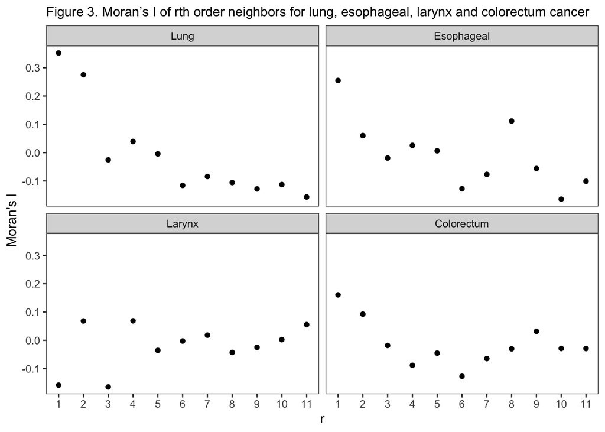

```r
projmat=cbind(ca.albersproj$x,ca.albersproj$y)
dmat=as.matrix(dist(projmat))
# Moran's I function
moranI <- function(y, A){
  n = length(y)
  nom_sum = 0
  den_sum = 0
  for(i in 1:n){
    den_sum = den_sum + (y[i]-mean(y))^2
    for(j in 1:n){
      nom_sum = nom_sum + A[i,j]*(y[i]-mean(y))*(y[j]-mean(y))
    }
  }
  return(n*nom_sum/sum(A)/den_sum)
}

lung_moran = c()
esophagus_moran = c()
larynx_moran = c()
colrect_moran = c()
for(lag in 1:11){
  A_1 <- as.matrix((dmat <= 0.01*lag & dmat > 0.01*(lag-1))*1)
  diag(A_1) = 0
  lung_moran[lag] <- as.numeric(moranI(rate_lung$Age_Adjusted_Rate, A_1))
  esophagus_moran[lag] <- as.numeric(moranI(rate_esophagus$Age_Adjusted_Rate, A_1))
  larynx_moran[lag] <- as.numeric(moranI(rate_larynx$Age_Adjusted_Rate, A_1))
  colrect_moran[lag] <- as.numeric(moranI(rate_colrect$Age_Adjusted_Rate, A_1))
}

moran_value = c(lung_moran, esophagus_moran, larynx_moran, colrect_moran)
cancer = c(rep("Lung", 11), rep("Esophageal", 11), rep("Larynx", 11), rep("Colorectum", 11))
df = data.frame(cancer)
df$moran_value = moran_value
df$r = rep(1:11, 4)
df$cancer = factor(df$cancer, levels = c("Lung", "Esophageal", "Larynx", "Colorectum"))

ggplot(df, aes(r, moran_value)) + geom_point() +
  ylab("Moran's I") + facet_wrap(~cancer) + theme_bw() +
  scale_x_continuous(breaks = 1:11) +
  ggtitle("Figure 3. Moran’s I of rth order neighbors for lung, esophageal, larynx and colorectum cancer") +
  theme(panel.grid.major = element_blank(),
        panel.grid.minor = element_blank(),
        plot.title = element_text(size=11))
```

##### 2.5.2 Association across cancers: Pearson’s correlation matrix

```r
cancer_rates = cbind(rate_lung$Age_Adjusted_Rate, rate_esophagus$Age_Adjusted_Rate, rate_larynx$Age_Adjusted_Rate, rate_colrect$Age_Adjusted_Rate)
colnames(cancer_rates) = c("Lung and Bronchus", "Esophageal", "Larynx", "Colon and Rectum")
cor_matrix <- rcorr(cancer_rates)
cor_matrix
```

```
##                   Lung and Bronchus Esophageal Larynx Colon and Rectum
## Lung and Bronchus              1.00       0.55   0.46             0.46
## Esophageal                     0.55       1.00   0.27            -0.02
## Larynx                         0.46       0.27   1.00             0.03
## Colon and Rectum               0.46      -0.02   0.03             1.00
##
## n= 58
##
##
## P
##                   Lung and Bronchus Esophageal Larynx Colon and Rectum
## Lung and Bronchus                   0.0000     0.0003 0.0002
## Esophageal        0.0000                       0.0414 0.9027
## Larynx            0.0003            0.0414            0.8252
## Colon and Rectum  0.0002            0.9027     0.8252
```

### 3. Conditional Multivariate DAGAR (MDAGAR) model for four cancers implemented in JAGS

We’ll use MDAGAR model to analyze the multivariate areal data for lung, esophageal, larynx and colorectal cancer. The order of cancers matters for model fitting. There are $4! = 24$ permutations for $4$ cancers.

```
 sink("MDAGAR.txt")
  cat("
      model
      {
      for(i in 1:2){
      Tau1[i, i] <- 1
      Tau2[i, i] <- 1
      Tau3[i, i] <- 1
      Tau4[i, i] <- 1

      for(j in 1:k){
      B1[i,j] <- 0
      B2[i,j] <- 0
      B3[i,j] <- 0
      B4[i,j] <- 0
      }
      }

      for(l in 1:(k-1)){
      for(h in (l+1):k){
      Tau1[l,h] <- 0
      Tau2[l,h] <- 0
      Tau3[l,h] <- 0
      Tau4[l,h] <- 0
      }
      }

      Tau1[2,1] <- 0
      Tau2[2,1] <- 0
      Tau3[2,1] <- 0
      Tau4[2,1] <- 0

      for (i in 3:k)
      {
      Tau1[i,i] <- (1 + (ns[i-1] - 1) * rho1^2) / (1 - rho1^2)
      Tau2[i,i] <- (1 + (ns[i-1] - 1) * rho2^2) / (1 - rho2^2)
      Tau3[i,i] <- (1 + (ns[i-1] - 1) * rho3^2) / (1 - rho3^2)
      Tau4[i,i] <- (1 + (ns[i-1] - 1) * rho4^2) / (1 - rho4^2)
      for(h in 1:(i-1)){
      Tau1[i,h] <- 0
      Tau2[i,h] <- 0
      Tau3[i,h] <- 0
      Tau4[i,h] <- 0
      }
      b1[i] <- rho1 / (1 + (ns[i-1] - 1) * rho1^2)
      b2[i] <- rho2 / (1 + (ns[i-1] - 1) * rho2^2)
      b3[i] <- rho3 / (1 + (ns[i-1] - 1) * rho3^2)
      b4[i] <- rho4 / (1 + (ns[i-1] - 1) * rho4^2)
      for(j in (udnei[(cn[i-1] + 1):(cn[i-1] + ns[i-1])])){
      B1[i,j] <- b1[i]
      B2[i,j] <- b2[i]
      B3[i,j] <- b3[i]
      B4[i,j] <- b4[i]
      }
      for(j in index1[((k)*(i-3)-cn[i-1]+1) : ((k)*(i-3)-cn[i-1] + (k - ns[i-1]))]){
      B1[i,j] <- 0
      B2[i,j] <- 0
      B3[i,j] <- 0
      B4[i,j] <- 0
      }
      }

      Q1 <- t(I - B1) %*% Tau1 %*% (I - B1)
      Q2 <- t(I - B2) %*% Tau2 %*% (I - B2)
      Q3 <- t(I - B3) %*% Tau3 %*% (I - B3)
      Q4 <- t(I - B4) %*% Tau4 %*% (I - B4)

      W1[1:k] ~ dmnorm(rep(0, k), tau1*Q1)
      W2[1:k] ~ dmnorm(rep(0, k), tau2*Q2)
      W3[1:k] ~ dmnorm(rep(0, k), tau3*Q3)
      W4[1:k] ~ dmnorm(rep(0, k), tau4*Q4)
      A21 <- eta021 * I + eta121 * Minc
      A31 <- eta031 * I + eta131 * Minc
      A32 <- eta032 * I + eta132 * Minc
      A41 <- eta041 * I + eta141 * Minc
      A42 <- eta042 * I + eta142 * Minc
      A43 <- eta043 * I + eta143 * Minc
      W[1:k] <- W1
      W[(k+1):(2*k)] <- A21 %*% W1 + W2
      W[(2*k+1):(3*k)] <- A31 %*% W1 + A32 %*% W[(k+1):(2*k)] + W3
      W[(3*k+1):(4*k)] <- A41 %*% W1 + A42 %*% W[(k+1):(2*k)] + A43 %*% W[(2*k+1):(3*k)] + W4
      for (i in 1:k)
      {
      mu[i] <- X[i,] %*% beta + W[i]
      Y[i] ~ dnorm(mu[i], taue1)
      loglik[i] <- logdensity.norm(Y[i], mu[i], taue1)
      }

      for (i in (k+1):(2*k))
      {
      mu[i] <- X[i,] %*% beta + W[i]
      Y[i] ~ dnorm(mu[i], taue2)
      loglik[i] <- logdensity.norm(Y[i], mu[i], taue2)
      }

      for (i in (2*k+1):(3*k))
      {
      mu[i] <- X[i,] %*% beta + W[i]
      Y[i] ~ dnorm(mu[i], taue3)
      loglik[i] <- logdensity.norm(Y[i], mu[i], taue3)
      }
      for (i in (3*k+1):(4*k))
      {
      mu[i] <- X[i,] %*% beta + W[i]
      Y[i] ~ dnorm(mu[i], taue4)
      loglik[i] <- logdensity.norm(Y[i], mu[i], taue4)
      }

      rho1 ~ dunif(0, 0.999)
      rho2 ~ dunif(0, 0.999)
      rho3 ~ dunif(0, 0.999)
      rho4 ~ dunif(0, 0.999)
      tau1 ~ dgamma(2, 0.1)
      tau2 ~ dgamma(2, 0.1)
      tau3 ~ dgamma(2, 0.1)
      tau4 ~ dgamma(2, 0.1)
      eta021 ~ dnorm(0, 0.01)
      eta121 ~ dnorm(0, 0.01)
      eta031 ~ dnorm(0, 0.01)
      eta131 ~ dnorm(0, 0.01)
      eta032 ~ dnorm(0, 0.01)
      eta132 ~ dnorm(0, 0.01)
      eta041 ~ dnorm(0, 0.01)
      eta141 ~ dnorm(0, 0.01)
      eta042 ~ dnorm(0, 0.01)
      eta142 ~ dnorm(0, 0.01)
      eta043 ~ dnorm(0, 0.01)
      eta143 ~ dnorm(0, 0.01)

      taue1 ~ dgamma(2, 1)
      taue2 ~ dgamma(2, 1)
      taue3 ~ dgamma(2, 1)
      taue4 ~ dgamma(2, 1)
      vare1 <- 1/taue1
      vare2 <- 1/taue2
      vare3 <- 1/taue3
      vare4 <- 1/taue4
      beta[1:nc] ~ dmnorm(rep(0,nc), (0.001*I1))
      }
      ", fill = TRUE)
  sink()
```

#### 3.1 Create 24 permutations for the four cancers

```r
q=4
rate_list = list(rate_lung1, rate_esophagus1, rate_larynx1, rate_colrect1)

orderindex = 1:q
models = permutations(n=q,r=q,v=orderindex,repeats.allowed=F)
```

#### 3.2 Run MDAGAR for all permutations

It may take up to 48 hours for models running in JAGS. Two sets of parameters are included for two JAGS Outputs: One for model selection with parameters for likelihood calculation only; The other one also include random effects for post-analysis.

```r
Ylist = list()
Xlist = list()
mcmc_list = list()
mcmc_list1 = list()
for(i in 1:nrow(models)){
  #print(i)

  rate_list1 = rate_list[models[i,]]

  Y1 = rate_list1[[1]]$rate[final_perm]
  Y2 = rate_list1[[2]]$rate[final_perm]
  Y3 = rate_list1[[3]]$rate[final_perm]
  Y4 = rate_list1[[4]]$rate[final_perm]

  X1 = as.matrix(cbind(1,rate_list1[[1]][,6:14]))[final_perm,]
  X2 = as.matrix(cbind(1,rate_list1[[2]][,6:14]))[final_perm,]
  X3 = as.matrix(cbind(1,rate_list1[[3]][,6:14]))[final_perm,]
  X4 = as.matrix(cbind(1,rate_list1[[4]][,6:14]))[final_perm,]

  Y = c(Y1,Y2,Y3,Y4)
  X = as.matrix(bdiag(bdiag(X1, X2), bdiag(X3,X4)))

  Ylist[[i]] = Y
  Xlist[[i]] = X

  nc = ncol(X)

   model.data <- list(k = n, index1 = index1, I = diag(n), nc = nc, I1 = diag(nc), Minc = Minc, ns = dni, cn = c(0, cni), udnei = udnei, X = X, Y = Y)

  model.inits <- rep(list(list(rho1 = 0.1, rho2 = 0.1, rho3 = 0.1, tau1 = 1, tau2 = 1, tau3 = 1, eta021 = 1, eta121 = 1, eta031 = 1, eta131 = 1, eta032 = 1, eta132 = 1, eta041 = 1, eta141 = 1, eta042 = 1, eta142 = 1, eta043 = 1, eta143 = 1, taue1 = 1, taue2 = 1, taue3 = 1, taue4 = 1, beta = rep(0, nc), W1 = rep(0.1, n), W2 = rep(0.1, n), W3 = rep(0.1, n), W4 = rep(0.1, n))),2)
  #parameters for model selection
  model.param2 <- c("beta", "rho1", "rho2", "rho3", "rho4", "tau1", "tau2", "tau3", "tau4", "eta021", "eta121",  "eta031", "eta131", "eta032", "eta132","eta041", "eta141", "eta042", "eta142", "eta043", "eta143", "vare1", "vare2", "vare3", "vare4")
  #parameters for post-analysis
 model.param <- c("beta", "rho1", "rho2", "rho3", "rho4", "tau1", "tau2", "tau3", "tau4", "eta021", "eta121",  "eta031", "eta131", "eta032", "eta132","eta041", "eta141", "eta042", "eta142", "eta043", "eta143", "vare1", "vare2", "vare3", "vare4", "W", "loglik")

  #Results for model selection
  result <- jags(model.data, model.inits, model.param2, "MDAGAR.txt",
                  n.chains = 2, n.iter = 30000,n.burnin = 15000, n.thin = 1)

 #Results for post-analysis
  result1 <- jags(model.data, model.inits, model.param, "MDAGAR.txt",
                  n.chains = 2, n.iter = 30000,n.burnin = 15000, n.thin = 1)

  mcmc_list[[i]] = result
  mcmc_list1[[i]] = result1
}
```

### 4. Model selection using bridge sampling

We use bridge sampling to estimate the log marginal likelihood and calculate the posterior model probability for each model.

#### 4.1 Functions used for model selection

Functions used for model selection are defined here.

```r
# joint precision matrix for MDAGAR
Dinv_new <- function(Rho, n, cn, ns, udnei,q){
  Tau <- list()
  B <- list()
  invD <- list()
  for(i in 1:q){
    Tau[[i]] <- diag(n)
    B[[i]] <- matrix(0, n, n)
    for(j in 3:n){
      Tau[[i]][j,j] <- (1 + (ns[j-1] - 1) * Rho[i]^2) / (1 - Rho[i]^2)
      for(k in (udnei[(cn[j-1] + 1):(cn[j-1] + ns[j-1])])){
        B[[i]][j,k] <- Rho[i] / (1 + (ns[j-1] - 1) * Rho[i]^2)
      }
    }
    invD[[i]] <- t(diag(n) - B[[i]]) %*% Tau[[i]] %*% (diag(n) - B[[i]])
  }
  return(invD)
}

#likelihood function
Likli_fun = function(samples.row, data){

  A21_est = diag(samples.row["eta021"], data$n) + samples.row["eta121"] * data$Minc
  A31_est = diag(samples.row["eta031"], data$n) + samples.row["eta131"] * data$Minc
  A32_est = diag(samples.row["eta032"], data$n) + samples.row["eta132"] * data$Minc
  A41_est = diag(samples.row["eta041"], data$n) + samples.row["eta141"] * data$Minc
  A42_est = diag(samples.row["eta042"], data$n) + samples.row["eta142"] * data$Minc
  A43_est = diag(samples.row["eta043"], data$n) + samples.row["eta143"] * data$Minc

  invD_est = Dinv_new(c(samples.row["rho1"],samples.row["rho2"],samples.row["rho3"],samples.row["rho4"]), data$n, data$cn, data$ns, data$udnei, q=4)
  G_est = as.matrix(bdiag(bdiag(1/samples.row["tau1"]*solve(invD_est[[1]]), 1/samples.row["tau2"]*solve(invD_est[[2]])),
                          bdiag(1/samples.row["tau3"]*solve(invD_est[[3]]), 1/samples.row["tau4"]*solve(invD_est[[4]]))))
  A_est = as.matrix(blockmatrix(names = c("0","A21","A31","A41","0","0","A32","A42","0","0","0","A43","0","0","0","0"),
                                A21=A21_est, A31=A31_est, A32=A32_est, A41=A41_est, A42=A42_est, A43=A43_est, dim=c(4,4)))
  L_est = solve(diag(4*data$n)-A_est)
  V_est = L_est%*%G_est%*%t(L_est)
  Sigma = diag(c(rep(samples.row["vare1"],data$n),rep(samples.row["vare2"],data$n),rep(samples.row[["vare3"]],data$n),rep(samples.row[["vare4"]],data$n)))
  Cov = V_est + Sigma
  Prec = solve(nearPD(Cov)$mat)
  beta = NULL
  for(par in 1:40){
    beta = c(beta, samples.row[paste("beta[", par, "]", sep="")])
  }
  mu = data$X%*%beta
  as.numeric(-2*data$n*log(2*pi) + 1/2*logdet(nearPD(Prec)$mat) - 1/2*t(data$Y-mu)%*%Prec%*%(data$Y-mu))
}

#unnormalized joint posterior function
log_posterior <- function(samples.row, data) {

  eta_sum = dnorm(samples.row["eta021"], 0, 10, log=T) + dnorm(samples.row["eta121"], 0, 10, log=T)+
    dnorm(samples.row["eta031"], 0, 10, log=T) + dnorm(samples.row["eta131"], 0, 10, log=T) +
    dnorm(samples.row["eta032"], 0, 10, log=T) + dnorm(samples.row["eta132"], 0, 10, log=T) +
    dnorm(samples.row["eta041"], 0, 10, log=T) + dnorm(samples.row["eta141"], 0, 10, log=T) +
    dnorm(samples.row["eta042"], 0, 10, log=T) + dnorm(samples.row["eta142"], 0, 10, log=T) +
    dnorm(samples.row["eta043"], 0, 10, log=T) + dnorm(samples.row["eta143"], 0, 10, log=T)


  rho_sum = dunif(samples.row["rho1"], 0, 0.999, log=T) + dunif(samples.row["rho2"], 0, 0.999, log=T) + dunif(samples.row["rho3"], 0, 0.999, log=T) + dunif(samples.row["rho4"], 0, 0.999, log=T)

  tau_sum = dgamma(samples.row["tau1"], 2, rate = 0.1, log=T) + dgamma(samples.row["tau2"], 2, rate = 0.1, log=T) + dgamma(samples.row["tau3"], 2, rate = 0.1, log=T) + dgamma(samples.row["tau4"], 2, rate = 0.1, log=T)

  sigma_sum = dinvgamma(samples.row["vare1"], 2, 1, log=T) + dinvgamma(samples.row["vare2"], 2, 1, log=T) + dinvgamma(samples.row["vare3"], 2, 1, log=T) + dinvgamma(samples.row["vare4"], 2, 1, log=T)

  beta = NULL
  for(par in 1:40){
    beta = c(beta, samples.row[paste("beta[", par, "]", sep="")])
  }
  beta_sum = dmnorm(beta, 0, diag(sqrt(1000),40), log=T)
  as.numeric(Likli_fun(samples.row, data) + eta_sum + rho_sum + tau_sum + sigma_sum + beta_sum)
}
```

#### 4.2 Calculate log marginal likelihood using bridge sampling

It takes up to 48 hours to run bridge sampling for 24 models. Instead, you can also read the RDS file (“model_bridge_jags.rds”) for bridge sampling results to save time.

```r
#upper and lower bound for parameters
cname <- colnames(mcmc_list[[1]]$BUGSoutput$sims.array[,1,c(1:40, 42:65)])
lb <- rep(-Inf, length(cname))
ub <- rep(Inf, length(cname))
names(lb) <- names(ub) <- cname
lb[53:64] <- 0
ub[53:56] <- 0.999

model.bridge = list()
for(model in 1:nrow(models)){
  #print(model)
  set.seed(12345)
  model.bridge[[model]] <- bridge_sampler(samples = mcmc_list[[model]],
                                          data = list(Y = Ylist[[model]], X = Xlist[[model]], Minc = Minc, n = n, ns = dni, cn = c(0, cni), udnei = udnei),
                                          log_posterior = log_posterior, lb = lb,
                                          ub = ub, maxiter = 100000, silent = TRUE
                                          )
}

logml = rep(0, 24)
for(i in 1:24){
  logml[i] = model.bridge[[i]]$logml
}
```

#### 4.3 Posterior model probabilities

Model $10$ gets the largest probability with the corresponding conditional structure $[\mbox{esophageal}] \times [\mbox{larynx} | \mbox{esophageal}] \times [\mbox{colorectal} | \mbox{esophageal}, \mbox{larynx}] \times [\mbox{lung} | \mbox{esophageal}, \mbox{larynx}, \mbox{colorectal}]$.

```r
post_prob = round(exp(logml)/sum(exp(logml)),4)
names(post_prob) = 1:24
post_prob
```

```
##      1      2      3      4      5      6      7      8      9     10     11
## 0.0000 0.0000 0.0000 0.0000 0.0000 0.0000 0.0000 0.0000 0.0000 0.9984 0.0000
##     12     13     14     15     16     17     18     19     20     21     22
## 0.0000 0.0000 0.0000 0.0000 0.0001 0.0000 0.0015 0.0000 0.0000 0.0000 0.0000
##     23     24
## 0.0000 0.0000
```

### 5. Post-analysis for parameter interpretation and correlation across space and diseases

The post-analysis is based on the results from the best model $M_{10}$. In addition, we also use Baysian model averaging (BMA) and obtain the model averaged estimates for spatial random effects and regression slopes.

#### 5.1 Functions for analysis

Functions used for post-analysis are defined here.

```r
# corr(w_1j, w_2j): correlation for two diseases in the same region
cor_fun = function(x){
  A21_est = diag(x[["eta0_21"]], n) + x[["eta1_21"]] * Minc
  A31_est = diag(x[["eta0_31"]], n) + x[["eta1_31"]] * Minc
  A32_est = diag(x[["eta0_32"]], n) + x[["eta1_32"]] * Minc
  A41_est = diag(x[["eta0_41"]], n) + x[["eta1_41"]] * Minc
  A42_est = diag(x[["eta0_42"]], n) + x[["eta1_42"]] * Minc
  A43_est = diag(x[["eta0_43"]], n) + x[["eta1_43"]] * Minc

  invD_est = Dinv_new(c(x[["rho1"]],x[["rho2"]],x[["rho3"]],x[["rho4"]]), n, cn, ns, udnei,q=4)
  G_est = as.matrix(bdiag(bdiag(1/x[["tausq1"]]*solve(invD_est[[1]]), 1/x[["tausq2"]]*solve(invD_est[[2]])),
                          bdiag(1/x[["tausq3"]]*solve(invD_est[[3]]), 1/x[["tausq4"]]*solve(invD_est[[4]]))))
  A_est = as.matrix(blockmatrix(names = c("0","A21","A31","A41","0","0","A32","A42","0","0","0","A43","0","0","0","0"),
                                A21=A21_est, A31=A31_est, A32=A32_est, A41=A41_est, A42=A42_est, A43=A43_est, dim=c(4,4)))
  L_est = solve(diag(4*n)-A_est)
  WV_est = L_est%*%G_est%*%t(L_est)
  Sigma_est = diag(c(rep(x[["sigmasq1"]],n),rep(x[["sigmasq2"]],n),rep(x[["sigmasq3"]],n),rep(x[["sigmasq4"]],n)))
  V_est = WV_est + Sigma_est


  cor12 = diag(V_est[1:58, (1+58):(58+58)])/sqrt(diag(V_est[1:58, 1:58])*diag(V_est[(1+58):(58+58), (1+58):(58+58)]))
  cor13 = diag(V_est[1:58, (1+58*2):(58+58*2)])/sqrt(diag(V_est[1:58, 1:58])*diag(V_est[(1+58*2):(58+58*2), (1+58*2):(58+58*2)]))
  cor14 = diag(V_est[1:58, (1+58*3):(58+58*3)])/sqrt(diag(V_est[1:58, 1:58])*diag(V_est[(1+58*3):(58+58*3), (1+58*3):(58+58*3)]))
  cor23 = diag(V_est[(1+58):(58+58), (1+58*2):(58+58*2)])/sqrt(diag(V_est[(1+58):(58+58), (1+58):(58+58)])*diag(V_est[(1+58*2):(58+58*2), (1+58*2):(58+58*2)]))
  cor24 = diag(V_est[(1+58):(58+58), (1+58*3):(58+58*3)])/sqrt(diag(V_est[(1+58):(58+58), (1+58):(58+58)])*diag(V_est[(1+58*3):(58+58*3), (1+58*3):(58+58*3)]))
  cor34 = diag(V_est[(1+58*2):(58+58*2), (1+58*3):(58+58*3)])/sqrt(diag(V_est[(1+58*2):(58+58*2), (1+58*2):(58+58*2)])*diag(V_est[(1+58*3):(58+58*3), (1+58*3):(58+58*3)]))

  return(c(cor12,cor13,cor14,cor23,cor24,cor34))
}

# Summary function for estimates
mysummary = function(invector) {
  c(mean(invector), median(invector), sd(invector), quantile(invector, .025), quantile(invector,.975))
}
```

#### 5.2 Estimates for parameters

Coefficients for covariates, spatial correlation parameter $\rho_i$, spatial precison of random effects $\tau_i$, and variance of random noise $\sigma_i^2$, $i = 1, 2, 3, 4$, for each disease are estimated in the table below. The estimates for covariates coefficients are obtained from both the best model $M_{10}$ and BMA, which are consistent with each other.

##### 5.2.1 Best model $M_{10}$

```r
mcmc_select <- mcmc_list1[[10]]
jags_result1 = mcmc_select$BUGSoutput$sims.array[,1,c(233:285,518:529)]
jags_result2 = mcmc_select$BUGSoutput$sims.array[,2,c(233:285,518:529)]
jags_result <- rbind(jags_result1, jags_result2)

colnames(jags_result) = c("beta1", "beta2","beta3","beta4","beta5", "beta6", "beta7","beta8","beta9","beta10","beta11","beta12",
                          "beta13", "beta14","beta15","beta16","beta17", "beta18", "beta19","beta20","beta21","beta22","beta23","beta24",
                          "beta25", "beta26","beta27","beta28","beta29", "beta30", "beta31","beta32","beta33","beta34","beta35","beta36",
                          "beta37","beta38","beta39","beta40", "deviance", "eta0_21", "eta0_31", "eta0_32", "eta0_41",
                          "eta0_42", "eta0_43", "eta1_21", "eta1_31", "eta1_32", "eta1_41", "eta1_42", "eta1_43", "rho1", "rho2", "rho3", "rho4",
                          "tausq1", "tausq2", "tausq3", "tausq4","sigmasq1","sigmasq2","sigmasq3","sigmasq4")
estimate1 <- round(t(apply(jags_result, 2, mysummary)),2)

# Table for coefficients
table_est = paste(estimate1[,1], " (", estimate1[,4], ", ", estimate1[,5], ")", sep="")


table1 <- data.frame(matrix(table_est[1:40], ncol = 4, byrow=F))
table2 <- data.frame(matrix(table_est[54:65], ncol = 4, byrow=T))

table <- rbind(table1, table2)
colnames(table) <- c("Esophagus", "Larynx", "Colorectum", "Lung")
table$Parameters <- c("Intercept", "Smoke", "Young", "Old", "Edu", "Unemp", "Black", "Male",
                      "Uninsure", "Poverty", "rho", "tau", "sigmasq")
table1 <- table[,c(5,1:4)]
knitr::kable(table1, caption = "Table 1. Posterior means (95% credible intervals) for parameters estimated from M_10")
```

Table 1. Posterior means (95% credible intervals) for parameters estimated from M_10

| Parameters | Esophagus | Larynx | Colorectum | Lung |
| --- | --- | --- | --- | --- |
| Intercept | 16.63 (3.95, 29.35) | 6.06 (-1.27, 13.43) | 18.4 (-11.4, 48.22) | 28.68 (-18.99, 73.7) |
| Smoke | 0.25 (0.13, 0.37) | 0.04 (-0.03, 0.11) | 0.24 (-0.1, 0.57) | 0.74 (0, 1.52) |
| Young | -0.12 (-0.31, 0.07) | -0.07 (-0.18, 0.04) | 0.27 (-0.19, 0.73) | -0.12 (-0.92, 0.71) |
| Old | -0.11 (-0.26, 0.04) | -0.05 (-0.14, 0.03) | 0.08 (-0.29, 0.45) | -0.18 (-0.91, 0.59) |
| Edu | 0.02 (-0.08, 0.12) | -0.02 (-0.08, 0.04) | 0.17 (-0.09, 0.44) | -0.19 (-0.67, 0.29) |
| Unemp | -0.13 (-0.29, 0.02) | 0.02 (-0.08, 0.11) | -0.13 (-0.56, 0.31) | 0.67 (-0.38, 1.62) |
| Black | 0.14 (-0.06, 0.34) | 0.14 (0.02, 0.25) | -0.15 (-0.68, 0.37) | 0.02 (-1.05, 1.06) |
| Male | -0.04 (-0.17, 0.09) | 0 (-0.08, 0.07) | 0.24 (-0.12, 0.62) | 0.03 (-0.66, 0.87) |
| Uninsure | -0.24 (-0.43, -0.04) | -0.07 (-0.18, 0.05) | 0.09 (-0.39, 0.57) | 0.07 (-0.69, 0.87) |
| Poverty | 0.29 (-0.25, 0.82) | 0.19 (-0.12, 0.51) | -0.16 (-1.58, 1.28) | 0.73 (-2.23, 3.75) |
| rho | 0.22 (0.01, 0.71) | 0.3 (0.01, 0.91) | 0.5 (0.03, 0.99) | 0.49 (0.03, 0.96) |
| tau | 28.29 (5.25, 66.9) | 27.38 (7.48, 64.1) | 19.19 (2.14, 53.29) | 19.49 (2.11, 54.65) |
| sigmasq | 1.67 (1.13, 2.46) | 0.46 (0.27, 0.71) | 8.28 (4.15, 13.54) | 1.05 (0.18, 4.42) |

##### 5.2.2 BMA estimates

```r
beta_model1 = list()
beta_model2 = list()
beta_model3 = list()
beta_model4 = list()

W_model1 = list()
W_model2 = list()
W_model3 = list()
W_model4 = list()

beta_model = data.frame(matrix(0, 40, 24))
W_model = data.frame(matrix(0, 232, 24))

# Samples and means for parameter estimates
for(i in 1:24){
#print(i)

  beta_result1 = mcmc_list1[[i]]$BUGSoutput$sims.array[,1,c(233:272)]
  beta_result2 = mcmc_list1[[i]]$BUGSoutput$sims.array[,2,c(233:272)]
  beta_est = data.frame(t(rbind(beta_result1, beta_result2)))
  beta_mean = data.frame(apply(beta_est, 1, mean))
  beta_mean$cancer = rep(models[i,], each = 10)
  beta_mean1 = beta_mean[order(beta_mean$cancer),][,1]
  beta_model[,i] = beta_mean1

  beta_est$cancer = rep(models[i,], each = 10)
  beta_list = split(beta_est, beta_est$cancer)
  beta_list = lapply(beta_list, function(x) x[, -ncol(x)])
  beta_model1[[i]] = beta_list[[1]]
  beta_model2[[i]] = beta_list[[2]]
  beta_model3[[i]] = beta_list[[3]]
  beta_model4[[i]] = beta_list[[4]]


  W_mcmc1 =  mcmc_list1[[i]]$BUGSoutput$sims.array[,1,1:232]
  W_mcmc2 =  mcmc_list1[[i]]$BUGSoutput$sims.array[,2,1:232]
  W_mcmc = data.frame(t(rbind(W_mcmc1, W_mcmc2)))
  W_mean = data.frame(apply(W_mcmc, 1, mean))
  W_mean$cancer = rep(models[i,], each = 58)
  W_mean1 = W_mean[order(W_mean$cancer),][,1]
  W_model[,i] = W_mean1

  W_mcmc$cancer = rep(models[i,], each = 58)
  W_list = split(W_mcmc, W_mcmc$cancer)
  W_list = lapply(W_list, function(x) x[, -ncol(x)])
  W_model1[[i]] = W_list[[1]]
  W_model2[[i]] = W_list[[2]]
  W_model3[[i]] = W_list[[3]]
  W_model4[[i]] = W_list[[4]]
}

# Sample beta and W from different models in terms of posterior model probabilities
set.seed(123)
model_select = sample(1:24, 10000, prob = post_prob, replace = TRUE)

beta1_avei = NULL
beta2_avei = NULL
beta3_avei = NULL
beta4_avei = NULL
W1_avei = NULL
W2_avei = NULL
W3_avei = NULL
W4_avei = NULL

for(i in 1:10000){
  #print(i)
  m = model_select[i]
  beta1_avei = cbind(beta1_avei, beta_model1[[m]][,i])
  beta2_avei = cbind(beta2_avei, beta_model2[[m]][,i])
  beta3_avei = cbind(beta3_avei, beta_model3[[m]][,i])
  beta4_avei = cbind(beta4_avei, beta_model4[[m]][,i])

  W1_avei = cbind(W1_avei, W_model1[[m]][,i])
  W2_avei = cbind(W2_avei, W_model2[[m]][,i])
  W3_avei = cbind(W3_avei, W_model3[[m]][,i])
  W4_avei = cbind(W4_avei, W_model4[[m]][,i])
}
beta1 <- round(t(apply(beta1_avei, 1, mysummary)),2)
beta2 <- round(t(apply(beta2_avei, 1, mysummary)),2)
beta3 <- round(t(apply(beta3_avei, 1, mysummary)),2)
beta4 <- round(t(apply(beta4_avei, 1, mysummary)),2)

W1 <- t(apply(W1_avei, 1, mysummary))
W2 <- t(apply(W2_avei, 1, mysummary))
W3 <- t(apply(W3_avei, 1, mysummary))
W4 <- t(apply(W4_avei, 1, mysummary))

#Model 10: 2, 3, 4, 1
beta_est <- rbind(beta2, beta3, beta4, beta1)
table_est = paste(beta_est[,1], " (", beta_est[,4], ", ", beta_est[,5], ")", sep="")
table1 <- data.frame(matrix(table_est, ncol = 4, byrow=F))
colnames(table1) <- c("Esophagus", "Larynx", "Colorectum",  "Lung")
rownames(table1) <- c("Intercept", "Smoke", "Young", "Old", "Edu", "Unemp", "Black", "Male",
                      "Uninsure", "Poverty")
knitr::kable(table1, caption = "Table 2. Posterior means (95% credible intervals) for BMA regression coefficients.")
```

Table 2. Posterior means (95% credible intervals) for BMA regression coefficients.

|  | Esophagus | Larynx | Colorectum | Lung |
| --- | --- | --- | --- | --- |
| Intercept | 16.99 (4.58, 29.8) | 6.01 (-1.02, 13.16) | 17.15 (-12.53, 46.27) | 31.22 (-12.9, 76.3) |
| Smoke | 0.25 (0.13, 0.37) | 0.04 (-0.03, 0.11) | 0.22 (-0.13, 0.55) | 0.67 (-0.19, 1.36) |
| Young | -0.12 (-0.31, 0.07) | -0.07 (-0.17, 0.04) | 0.27 (-0.18, 0.72) | -0.17 (-0.93, 0.56) |
| Old | -0.11 (-0.26, 0.03) | -0.06 (-0.14, 0.03) | 0.08 (-0.27, 0.45) | -0.23 (-0.92, 0.47) |
| Edu | 0.02 (-0.09, 0.12) | -0.02 (-0.08, 0.03) | 0.18 (-0.08, 0.44) | -0.21 (-0.68, 0.25) |
| Unemp | -0.14 (-0.3, 0.02) | 0.02 (-0.07, 0.11) | -0.12 (-0.56, 0.32) | 0.75 (-0.14, 1.75) |
| Black | 0.15 (-0.05, 0.34) | 0.13 (0.01, 0.24) | -0.16 (-0.68, 0.36) | -0.01 (-1.06, 1.02) |
| Male | -0.04 (-0.17, 0.09) | -0.01 (-0.08, 0.07) | 0.24 (-0.11, 0.61) | -0.03 (-0.67, 0.76) |
| Uninsure | -0.24 (-0.44, -0.04) | -0.06 (-0.18, 0.05) | 0.12 (-0.34, 0.59) | 0.07 (-0.71, 0.83) |
| Poverty | 0.29 (-0.23, 0.83) | 0.2 (-0.11, 0.51) | -0.17 (-1.57, 1.23) | 0.97 (-1.84, 3.76) |

#### 5.3 Posterior mean random effects estimated from $M_{10}$ and BMA

##### 5.3.1 Best model $M_{10}$

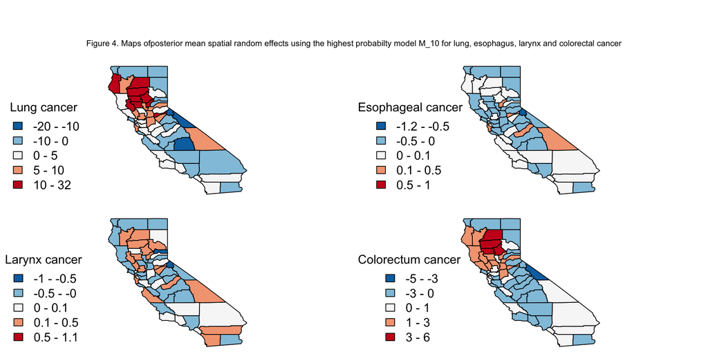

```r
W_mcmc1 =  mcmc_select$BUGSoutput$sims.array[,1,1:232]
W_mcmc2 =  mcmc_select$BUGSoutput$sims.array[,2,1:232]
W_mcmc = rbind(W_mcmc1, W_mcmc2)

W_mean = apply(W_mcmc, 2, mean)
W_mean1 = W_mean[1:58]
ca.poly$W_mean1 = W_mean1[order(final_perm)]
brks_fit1 = c(-1.2, -0.5, 0, 0.1, 0.5, 1)
color.pallete = rev(brewer.pal(5,"RdBu"))
class.W1 = classIntervals(var=ca.poly$W_mean1, n=5, style="fixed",
                          fixedBreaks=brks_fit1, dataPrecision=4)
color.code.W1 = findColours(class.W1, color.pallete)

W_mean2 = W_mean[59:116]
ca.poly$W_mean2 = W_mean2[order(final_perm)]
brks_fit2 = c(-1, -0.5, 0, 0.1, 0.5, 1.1)
class.W2 = classIntervals(var=ca.poly$W_mean2, n=5, style="fixed",
                          fixedBreaks=brks_fit2, dataPrecision=4)
color.code.W2 = findColours(class.W2, color.pallete)

W_mean3 = W_mean[117:174]
ca.poly$W_mean3 = W_mean3[order(final_perm)]
brks_fit3 = c(-5, -3, 0, 1, 3, 6)
class.W3 = classIntervals(var=ca.poly$W_mean3, n=5, style="fixed",
                          fixedBreaks=brks_fit3, dataPrecision=4)
color.code.W3 = findColours(class.W3, color.pallete)

W_mean4 = W_mean[175:232]
ca.poly$W_mean4 = W_mean4[order(final_perm)]
brks_fit4 = c(-20, -10, 0, 5, 10, 32)
class.W4 = classIntervals(var=ca.poly$W_mean4, n=5, style="fixed",
                          fixedBreaks=brks_fit4, dataPrecision=4)
color.code.W4 = findColours(class.W4, color.pallete)

# Plots for random effects
par(mfrow=c(2,2), oma = c(0,0,4,0) + 0.1, mar = c(0,0,1,0) + 0.1)

plot(ca.poly, col = color.code.W4)
leg.txt1 = c("-20 - -10", "-10 - 0", "0 - 5", "5 - 10", "10 - 32")
legend("bottomleft", title="Lung cancer",legend=leg.txt1, cex=1.25, bty="n", horiz = FALSE,
       fill = color.pallete)

plot(ca.poly, col = color.code.W1)
leg.txt2 = c("-1.2 - -0.5", "-0.5 - 0", "0 - 0.1", "0.1 - 0.5", "0.5 - 1")
legend("bottomleft", title="Esophageal cancer", legend=leg.txt2, xpd = TRUE, cex=1.25, bty="n", horiz = FALSE,
       fill = color.pallete)

plot(ca.poly, col = color.code.W2)
leg.txt3 = c("-1 - -0.5", "-0.5 - -0", "0 - 0.1", "0.1 - 0.5", "0.5 - 1.1")
legend("bottomleft", title="Larynx cancer", legend=leg.txt3, xpd = TRUE, cex=1.25, bty="n", horiz = FALSE,
       fill = color.pallete)

plot(ca.poly, col = color.code.W3)
leg.txt4 = c("-5 - -3", "-3 - 0", "0 - 1", "1 - 3", "3 - 6")
legend("bottomleft",title="Colorectum cancer", legend=leg.txt4, cex=1.25, bty="n", horiz = FALSE,
       fill = color.pallete)
mtext("Figure 4. Maps ofposterior mean spatial random effects using the highest probabilty model M_10 for lung, esophagus, larynx and colorectal cancer", outer = TRUE, cex = 0.7)
```

##### 5.3.2 BMA estimates

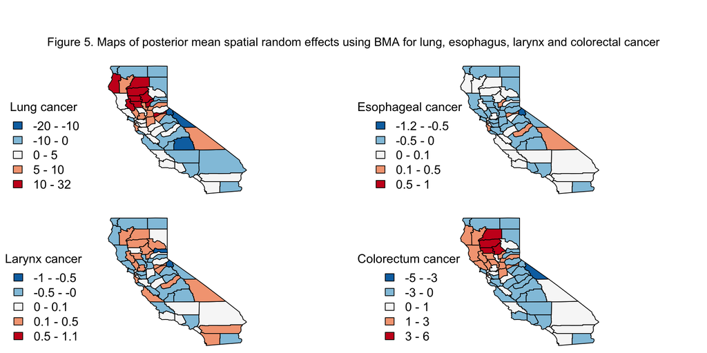

```r
W_wm = data.frame(t(apply(W_model, 1, function(x) x * post_prob)))
W_wmean = rowSums(W_wm)


W_mean1 = W_wmean[1:58]
ca.poly$W_mean1 = W_mean1[order(final_perm)]
brks_fit1 = c(-20, -10, 0, 5, 10, 32)
color.pallete = rev(brewer.pal(5,"RdBu"))
class.W1 = classIntervals(var=ca.poly$W_mean1, n=5, style="fixed",
                          fixedBreaks=brks_fit1, dataPrecision=4)
color.code.W1 = findColours(class.W1, color.pallete)


W_mean2 = W_wmean[59:116]
ca.poly$W_mean2 = W_mean2[order(final_perm)]
brks_fit2 = c(-1.2, -0.5, 0, 0.1, 0.5, 1)
class.W2 = classIntervals(var=ca.poly$W_mean2, n=5, style="fixed",
                          fixedBreaks=brks_fit2, dataPrecision=4)
color.code.W2 = findColours(class.W2, color.pallete)

W_mean3 = W_wmean[117:174]
ca.poly$W_mean3 = W_mean3[order(final_perm)]
brks_fit3 = c(-1, -0.5, 0, 0.1, 0.5, 1.1)
class.W3 = classIntervals(var=ca.poly$W_mean3, n=5, style="fixed",
                          fixedBreaks=brks_fit3, dataPrecision=4)
color.code.W3 = findColours(class.W3, color.pallete)

W_mean4 = W_wmean[175:232]
ca.poly$W_mean4 = W_mean4[order(final_perm)]
brks_fit4 = c(-5, -3, 0, 1, 3, 6)
class.W4 = classIntervals(var=ca.poly$W_mean4, n=5, style="fixed",
                          fixedBreaks=brks_fit4, dataPrecision=4)
color.code.W4 = findColours(class.W4, color.pallete)

# Plots for random effects
par(mfrow=c(2,2), oma = c(0,0,4,0) + 0.1, mar = c(0,0,1,0) + 0.1)

plot(ca.poly, col = color.code.W1)
leg.txt = c("-20 - -10", "-10 - 0", "0 - 5", "5 - 10", "10 - 32")
legend("bottomleft", title="Lung cancer",legend=leg.txt, cex=1.25, bty="n", horiz = FALSE,
       fill = color.pallete)

plot(ca.poly, col = color.code.W2)
leg.txt = c("-1.2 - -0.5", "-0.5 - 0", "0 - 0.1", "0.1 - 0.5", "0.5 - 1")
legend("bottomleft", title="Esophageal cancer", legend=leg.txt, xpd = TRUE, cex=1.25, bty="n", horiz = FALSE,
       fill = color.pallete)

plot(ca.poly, col = color.code.W3)
leg.txt = c("-1 - -0.5", "-0.5 - -0", "0 - 0.1", "0.1 - 0.5", "0.5 - 1.1")
legend("bottomleft", title="Larynx cancer", legend=leg.txt, xpd = TRUE, cex=1.25, bty="n", horiz = FALSE,
       fill = color.pallete)

plot(ca.poly, col = color.code.W4)
leg.txt = c("-5 - -3", "-3 - 0", "0 - 1", "1 - 3", "3 - 6")
legend("bottomleft",title="Colorectum cancer", legend=leg.txt, cex=1.25, bty="n", horiz = FALSE,
       fill = color.pallete)

mtext("Figure 5. Maps of posterior mean spatial random effects using BMA for lung, esophagus, larynx and colorectal cancer", outer = TRUE, cex = 1)
```

#### 5.4 Posterior mean incidence rates estimated from $M_{10}$ and BMA

##### 5.4.1 Best model $M_{10}$

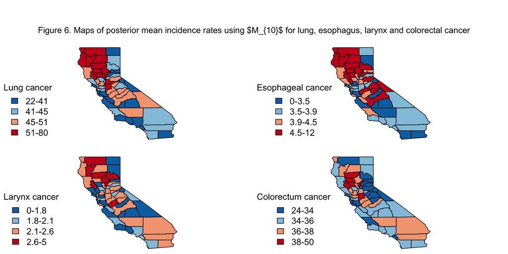

```r
rate_list1 = rate_list[models[10,]]

Y1 = rate_list1[[1]]$rate[final_perm]
Y2 = rate_list1[[2]]$rate[final_perm]
Y3 = rate_list1[[3]]$rate[final_perm]
Y4 = rate_list1[[4]]$rate[final_perm]

X1 = as.matrix(cbind(1, rate_list1[[1]][,6:14]))[final_perm,]
X2 = as.matrix(cbind(1, rate_list1[[2]][,6:14]))[final_perm,]
X3 = as.matrix(cbind(1, rate_list1[[3]][,6:14]))[final_perm,]
X4 = as.matrix(cbind(1, rate_list1[[4]][,6:14]))[final_perm,]

Y = c(Y1,Y2,Y3,Y4)
X = as.matrix(bdiag(bdiag(X1, X2), bdiag(X3,X4)))

y.est = matrix(0,30000,4*n)
for(iter in 1:30000){
  #print(iter)
  y.est[iter,] = as.vector(X %*% as.vector(jags_result[iter, 1:40]) + W_mcmc[iter,])
}
y.mean = apply(y.est,2,mean)

ca.poly$rate_esophagus_est = y.mean[1:58][order(final_perm)]
ca.poly$rate_larynx_est = y.mean[59:116][order(final_perm)]
ca.poly$rate_colrect_est = y.mean[117:174][order(final_perm)]
ca.poly$rate_lung_est = y.mean[175:232][order(final_perm)]


brks_fit_lung = c(22, 41, 45, 51, 80)
brks_fit_esophagus = c(0, 3.5, 3.9, 4.5, 12)
brks_fit_larynx = c(0, 1.8, 2.1, 2.6, 5)
brks_fit_colrect = c(24, 34, 36, 38, 50)


color.pallete = rev(brewer.pal(4,"RdBu"))
class.rate_lung = classIntervals(var=ca.poly$rate_lung_est, n=4, style="fixed",
                                 fixedBreaks=brks_fit_lung, dataPrecision=4)
class.rate_esophagus = classIntervals(var=ca.poly$rate_esophagus_est, n=4, style="fixed",
                                      fixedBreaks=brks_fit_esophagus, dataPrecision=4)
class.rate_larynx = classIntervals(var=ca.poly$rate_larynx_est, n=4, style="fixed",
                                   fixedBreaks=brks_fit_larynx, dataPrecision=4)
class.rate_colrect = classIntervals(var=ca.poly$rate_colrect_est, n=4, style="fixed",
                                    fixedBreaks=brks_fit_colrect, dataPrecision=4)
color.code.rate_lung = findColours(class.rate_lung, color.pallete)
color.code.rate_esophagus = findColours(class.rate_esophagus, color.pallete)
color.code.rate_larynx = findColours(class.rate_larynx, color.pallete)
color.code.rate_colrect = findColours(class.rate_colrect, color.pallete)

par(mfrow=c(2,2), oma = c(0,0,4,0) + 0.1, mar = c(0,0,1,0) + 0.1)

plot(ca.poly, col = color.code.rate_lung)
leg.txt1 = c("22-41", "41-45", "45-51","51-80")
legend("bottomleft", title="Lung cancer", legend=leg.txt1, cex=1.25, bty="n", horiz = FALSE,
       fill = color.pallete)

plot(ca.poly, col = color.code.rate_esophagus)
leg.txt2 = c("0-3.5", "3.5-3.9", "3.9-4.5", "4.5-12")
legend("bottomleft", title="Esophageal cancer",legend=leg.txt2, cex=1.25, bty="n", horiz = FALSE,
       fill = color.pallete)

plot(ca.poly, col = color.code.rate_larynx)
leg.txt3 = c("0-1.8", "1.8-2.1", "2.1-2.6", "2.6-5")
legend("bottomleft", title="Larynx cancer",legend=leg.txt3, cex=1.25, bty="n", horiz = FALSE,
       fill = color.pallete)

plot(ca.poly, col = color.code.rate_colrect)
leg.txt4 = c("24-34", "34-36", "36-38", "38-50")
legend("bottomleft",title="Colorectum cancer", legend=leg.txt4, cex=1.25, bty="n", horiz = FALSE,
       fill = color.pallete)
mtext("Figure 6. Maps of posterior mean incidence rates using $M_{10}$ for lung, esophagus, larynx and colorectal cancer", outer = TRUE, cex = 1)
```

##### 5.4.2 BMA estimates

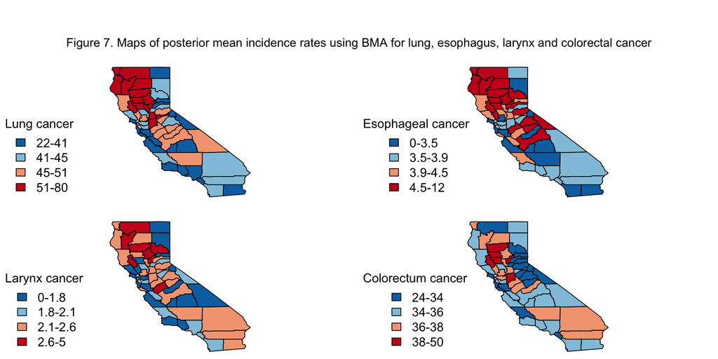

```r
beta_wm = data.frame(t(apply(beta_model, 1, function(x) x * post_prob)))
beta_wmean = rowSums(beta_wm)
y.mean = as.vector(X %*% as.vector(beta_wmean) + W_wmean)

ca.poly$rate_lung_est = y.mean[1:58][order(final_perm)]
ca.poly$rate_esophagus_est = y.mean[59:116][order(final_perm)]
ca.poly$rate_larynx_est = y.mean[117:174][order(final_perm)]
ca.poly$rate_colrect_est = y.mean[175:232][order(final_perm)]

brks_fit_lung = c(22, 41, 45, 51, 80)
brks_fit_esophagus = c(0, 3.5, 3.9, 4.5, 12)
brks_fit_larynx = c(0, 1.8, 2.1, 2.6, 5)
brks_fit_colrect = c(24, 34, 36, 38, 50)

color.pallete = rev(brewer.pal(4,"RdBu"))
class.rate_lung = classIntervals(var=ca.poly$rate_lung_est, n=4, style="fixed",
                                 fixedBreaks=brks_fit_lung, dataPrecision=4)
class.rate_esophagus = classIntervals(var=ca.poly$rate_esophagus_est, n=4, style="fixed",
                                      fixedBreaks=brks_fit_esophagus, dataPrecision=4)
class.rate_larynx = classIntervals(var=ca.poly$rate_larynx_est, n=4, style="fixed",
                                   fixedBreaks=brks_fit_larynx, dataPrecision=4)
class.rate_colrect = classIntervals(var=ca.poly$rate_colrect_est, n=4, style="fixed",
                                    fixedBreaks=brks_fit_colrect, dataPrecision=4)
color.code.rate_lung = findColours(class.rate_lung, color.pallete)
color.code.rate_esophagus = findColours(class.rate_esophagus, color.pallete)
color.code.rate_larynx = findColours(class.rate_larynx, color.pallete)
color.code.rate_colrect = findColours(class.rate_colrect, color.pallete)

par(mfrow=c(2,2), oma = c(0,0,4,0) + 0.1, mar = c(0,0,1,0) + 0.1)

plot(ca.poly, col = color.code.rate_lung)
leg.txt1 = c("22-41", "41-45", "45-51","51-80")
legend("bottomleft", title="Lung cancer", legend=leg.txt1, cex=1.25, bty="n", horiz = FALSE,
       fill = color.pallete)

plot(ca.poly, col = color.code.rate_esophagus)
leg.txt2 = c("0-3.5", "3.5-3.9", "3.9-4.5", "4.5-12")
legend("bottomleft", title="Esophageal cancer",legend=leg.txt2, cex=1.25, bty="n", horiz = FALSE,
       fill = color.pallete)

plot(ca.poly, col = color.code.rate_larynx)
leg.txt3 = c("0-1.8", "1.8-2.1", "2.1-2.6", "2.6-5")
legend("bottomleft", title="Larynx cancer",legend=leg.txt3, cex=1.25, bty="n", horiz = FALSE,
       fill = color.pallete)

plot(ca.poly, col = color.code.rate_colrect)
leg.txt4 = c("24-34", "34-36", "36-38", "38-50")
legend("bottomleft",title="Colorectum cancer", legend=leg.txt4, cex=1.25, bty="n", horiz = FALSE,
       fill = color.pallete)
mtext("Figure 7. Maps of posterior mean incidence rates using BMA for lung, esophagus, larynx and colorectal cancer", outer = TRUE, cex = 1)
```

#### 5.5 Post-analysis for association across cancers

The post-analysis for association across cancers utilize results from $M_{10}$ only.

##### 5.5.1 Histogram for posterior samples of linking parameter $\eta$s

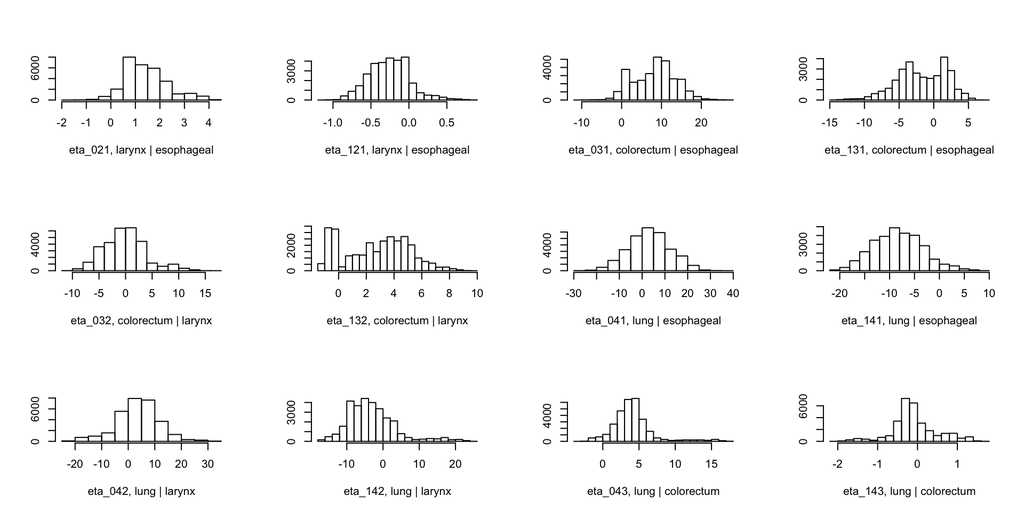

```r
par(mfrow=c(3,4))
hist(jags_result[,42],xlab = "eta_021, larynx | esophageal",ylab = "", main="")
hist(jags_result[,48],xlab = "eta_121, larynx | esophageal",ylab = "", main="")
hist(jags_result[,43],xlab = "eta_031, colorectum | esophageal",ylab = "", main="")
hist(jags_result[,49],xlab = "eta_131, colorectum | esophageal",ylab = "", main="")
hist(jags_result[,44],xlab = "eta_032, colorectum | larynx",ylab = "", main="")
hist(jags_result[,50],xlab = "eta_132, colorectum | larynx",ylab = "", main="")
hist(jags_result[,45],xlab = "eta_041, lung | esophageal",ylab = "", main="")
hist(jags_result[,51],xlab = "eta_141, lung | esophageal",ylab = "", main="")
hist(jags_result[,46],xlab = "eta_042, lung | larynx",ylab = "", main="")
hist(jags_result[,52],xlab = "eta_142, lung | larynx",ylab = "", main="")
hist(jags_result[,47],xlab = "eta_043, lung | colorectum",ylab = "", main="")
hist(jags_result[,53],xlab = "eta_143, lung | colorectum",ylab = "", main="")
```

##### 5.5.2 Correlations of spatial random effects across cancers in each region

Here plots the posterior estimates for $corr(w_{ij}, w_{i'j})$ in each county $j$, $i \neq i'$. The yellow points indicate significant correlation in the county.

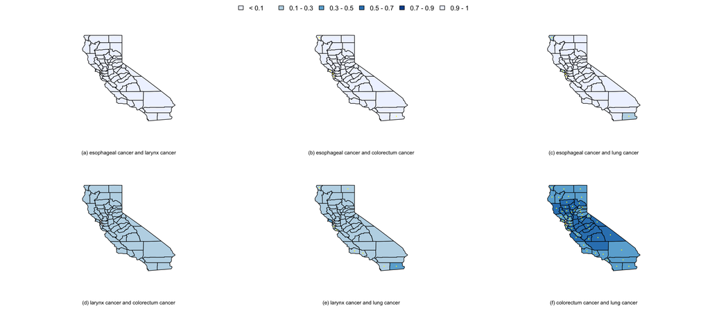

```r
cor_gibbs = apply(jags_result,1,cor_fun)
cor_gibbs_est = apply(cor_gibbs,1,mysummary)

cor_gibbs_est12 = t(cor_gibbs_est[,1:58])
cor_gibbs_est13 = t(cor_gibbs_est[,(1+58):(58+58)])
cor_gibbs_est14 = t(cor_gibbs_est[,(1+58*2):(58+58*2)])
cor_gibbs_est23 = t(cor_gibbs_est[,(1+58*3):(58+58*3)])
cor_gibbs_est24 = t(cor_gibbs_est[,(1+58*4):(58+58*4)])
cor_gibbs_est34 = t(cor_gibbs_est[,(1+58*5):(58+58*5)])

ca.poly$rate12 = cor_gibbs_est12[,1][order(final_perm)]
ca.poly$rate13 = cor_gibbs_est13[,1][order(final_perm)]
ca.poly$rate14 = cor_gibbs_est14[,1][order(final_perm)]
ca.poly$rate23 = cor_gibbs_est23[,1][order(final_perm)]
ca.poly$rate24 = cor_gibbs_est24[,1][order(final_perm)]
ca.poly$rate34 = cor_gibbs_est34[,1][order(final_perm)]
ca.poly$sig12 = 0
ca.poly$sig12[which(cor_gibbs_est12[,4][order(final_perm)] > 0 | cor_gibbs_est12[,5][order(final_perm)] < 0)] = 1
ca.poly$sig13 = 0
ca.poly$sig13[which(cor_gibbs_est13[,4][order(final_perm)] > 0 | cor_gibbs_est13[,5][order(final_perm)] < 0)] = 1
ca.poly$sig14 = 0
ca.poly$sig14[which(cor_gibbs_est14[,4][order(final_perm)] > 0 | cor_gibbs_est14[,5][order(final_perm)] < 0)] = 1
ca.poly$sig23 = 0
ca.poly$sig23[which(cor_gibbs_est23[,4][order(final_perm)] > 0 | cor_gibbs_est23[,5][order(final_perm)] < 0)] = 1
ca.poly$sig24 = 0
ca.poly$sig24[which(cor_gibbs_est24[,4][order(final_perm)] > 0 | cor_gibbs_est24[,5][order(final_perm)] < 0)] = 1
ca.poly$sig34 = 0
ca.poly$sig34[which(cor_gibbs_est34[,4][order(final_perm)] > 0 | cor_gibbs_est34[,5][order(final_perm)] < 0)] = 1

## Plots for correlation in each county
brks_fit = c(-0.5, 0.1, 0.3, 0.5, 0.7, 0.8)
color.pallete = brewer.pal(5,"Blues")
class.rate12 = classIntervals(var=ca.poly$rate12, n=5, style="fixed",
                              fixedBreaks=brks_fit, dataPrecision=4)
class.rate13 = classIntervals(var=ca.poly$rate13, n=5, style="fixed",
                              fixedBreaks=brks_fit, dataPrecision=4)
class.rate14 = classIntervals(var=ca.poly$rate14, n=5, style="fixed",
                              fixedBreaks=brks_fit, dataPrecision=4)
class.rate23 = classIntervals(var=ca.poly$rate23, n=5, style="fixed",
                              fixedBreaks=brks_fit, dataPrecision=4)
class.rate24 = classIntervals(var=ca.poly$rate24, n=5, style="fixed",
                              fixedBreaks=brks_fit, dataPrecision=4)
class.rate34 = classIntervals(var=ca.poly$rate34, n=5, style="fixed",
                              fixedBreaks=brks_fit, dataPrecision=4)
color.code.rate12 = findColours(class.rate12, color.pallete)
color.code.rate13 = findColours(class.rate13, color.pallete)
color.code.rate14 = findColours(class.rate14, color.pallete)
color.code.rate23 = findColours(class.rate23, color.pallete)
color.code.rate24 = findColours(class.rate24, color.pallete)
color.code.rate34 = findColours(class.rate34, color.pallete)


par(mfrow=c(2,3), oma = c(4, 1, 1, 1))
leg.txt = c("< 0.1", "0.1 - 0.3", "0.3 - 0.5", "0.5 - 0.7", "0.7 - 0.9", "0.9 - 1")

plot(ca.poly, col = color.code.rate12)
title(sub="(a) esophageal cancer and larynx cancer")
points(ca.coords[which(ca.poly$sig12==1),1], ca.coords[which(ca.poly$sig12==1),2], pch=10, col="yellow", cex=0.2)

plot(ca.poly, col = color.code.rate13)
title(sub="(b) esophageal cancer and colorectum cancer" )
points(ca.coords[which(ca.poly$sig14==1),1], ca.coords[which(ca.poly$sig14==1),2], pch=10, col="yellow", cex=0.2)

plot(ca.poly, col = color.code.rate14)
title(sub="(c) esophageal cancer and lung cancer" )
points(ca.coords[which(ca.poly$sig14==1),1], ca.coords[which(ca.poly$sig14==1),2], pch=10, col="yellow", cex=0.2)

plot(ca.poly, col = color.code.rate23)
title(sub="(d) larynx cancer and colorectum cancer" )
points(ca.coords[which(ca.poly$sig23==1),1], ca.coords[which(ca.poly$sig23==1),2], pch=10, col="yellow", cex=0.2)

plot(ca.poly, col = color.code.rate24)
title(sub="(e) larynx cancer and lung cancer" )
points(ca.coords[which(ca.poly$sig24==1),1], ca.coords[which(ca.poly$sig24==1),2], pch=10, col="yellow", cex=0.2)


plot(ca.poly, col = color.code.rate34)
title(sub="(f) colorectum cancer and lung cancer" )
points(ca.coords[which(ca.poly$sig34==1),1], ca.coords[which(ca.poly$sig34==1),2], pch=10, col="yellow", cex=0.2)


par(fig = c(0, 1, 0, 1), oma = c(0, 0, 0, 0), mar = c(0, 0, 0, 0), new = TRUE)
plot(0, 0, type = "n", bty = "n", xaxt = "n", yaxt = "n")
legend("top", legend=leg.txt, xpd = TRUE, cex=1.25, bty="n", horiz = TRUE,
       fill = color.pallete)
mtext("Figure 8. Estimated correlation between each pair of cancers in each of 58 counties of California", outer = TRUE, cex = 1)
```